# Reproducible Research : Course Project 1

## Loading and preprocessing the data

Before beggining, the working directory must be set where the file `activity.csv` is located. This can be done with the setwd() command. Loading packages *dplyr*, *lubridate* and *ggplot2*. Reading the table and transforming date variable into POSIXct.

```r
library(dplyr)
```

```r
library(lubridate)
library(ggplot2)

activity <- read.csv("activity.csv")
activity$date <- ymd(activity$date)
```

## What is mean total number of steps taken per day?

Using dplyr *group_by* and *summarize*, creating a dataframe containing the total number of steps per day. Then creating histogram with the qplot function.

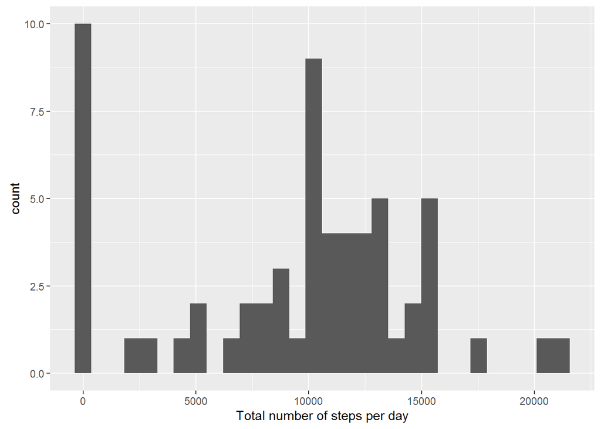

```r
activity_day <- (activity %>% group_by(date))

totalsteps <- summarize(activity_day, sum_steps=sum(steps, na.rm=TRUE))

qplot(sum_steps, data=totalsteps, xlab="Total number of steps per day")
```

## What is mean total number of steps taken per day?

The mean and median number of steps per day are calculated with the same dataframe.

```r
meansteps <- mean(totalsteps$sum_steps, na.rm=TRUE)
mediansteps <- median(totalsteps$sum_steps, na.rm=TRUE)
```

The mean is **9354.2295082**. The median is **10395**

## What is the average daily activity pattern?

This time, we are grouping the dataframe by interval with *group_by*.

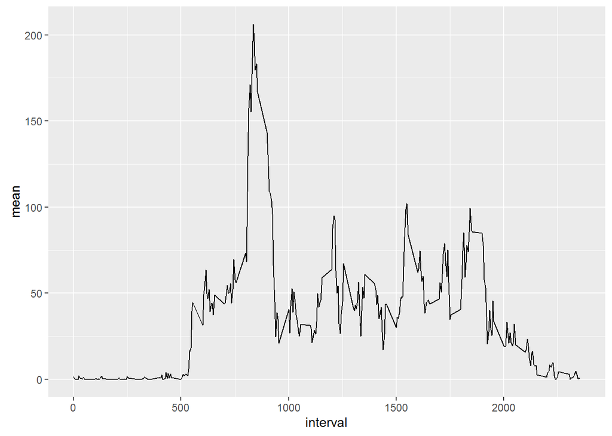

```r
activity_interval <- (activity %>% group_by(interval))

meaninterval <- summarize(activity_interval, mean=mean(steps, na.rm=TRUE))

qplot(interval, mean, data=meaninterval, geom="line")
```

```r
maxinterval <- filter(meaninterval, mean==max(mean))$interval
```

The 5-minute interval that, on average, contains the maximum number of steps is interval **835**.

## Imputing missing values

Calculate and report the total number of missing values in the dataset (i.e. the total number of rows with NAs)

```r
NA_number <- sum(is.na(activity$steps))
```

The number of missing value is **2304**.

## Filling the missing values for each interval with the mean for that 5-minute interval.

We are merging the dataframe activity and meaninterval. For each row, we now have the original steps value (which may be NA) and the mean value for that interval (mean variable). For each step value, creating the fill variable containing the mean value in case of NA value or containing 0 if the value is not NA. Finally, adding this value to the steps value.

```r
activity_filled <- merge(activity, meaninterval, by="interval")

## column "fill" containing value for filling
activity_filled$fill <- is.na(activity_filled$steps)*activity_filled$mean
activity_filled$steps <- rowSums(activity_filled[,c("steps","fill")], na.rm=TRUE)

## Create a new dataset that is equal to the original dataset but with the missing data filled in.

activity_filled <- select(activity_filled, 1:3)
```

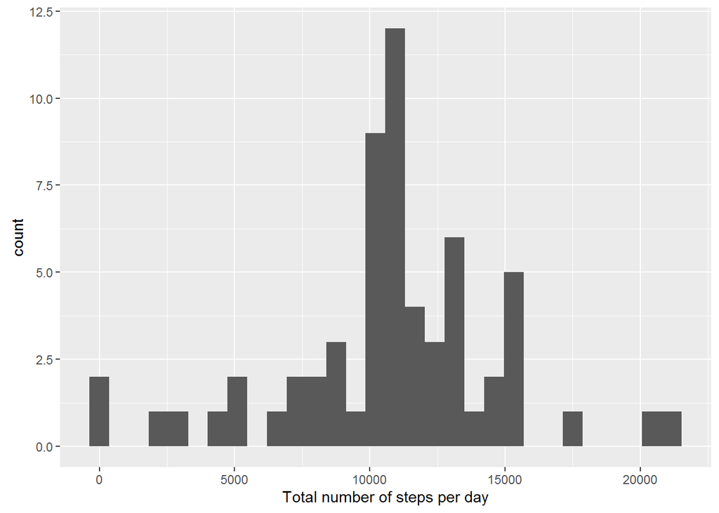

```r
activity_filled_day <- (activity_filled %>% group_by(date))

totalsteps_filled <- summarize(activity_filled_day, sum_steps=sum(steps))

## Histogram
qplot(sum_steps, data=totalsteps_filled, xlab="Total number of steps per day")
```

```r
meansteps_f <- mean(totalsteps_filled$sum_steps)
mediansteps_f <- median(totalsteps_filled$sum_steps)
```

## Are there differences in activity patterns between weekdays and weekends?

Create a new factor variable in the dataset with two levels: weekday and weekend indicating whether a given date is a weekday or weekend day.

```r
weekday <- function(x) {
        day <- weekdays(x)
        if (day %in% c("segunda-feira", "terÃ§a-feira", "quarta-feira",
                       "quinta-feira", "sexta-feira"))
                "weekday"
        else "weekend"
}

activity_filled$day <- sapply(activity_filled$date, weekday)
activity_filled$day <- as.factor(activity_filled$day)
```

Make a panel plot containing a time series plot (i.e. type = “l”) of the 5-minute interval (x-axis) and the average number of steps taken, averaged across all weekday days or weekend days (y-axis). We are grouping the dataframe by interval and day type (weekday and weekend). Then making a plot with ggplot and facet_wrap.

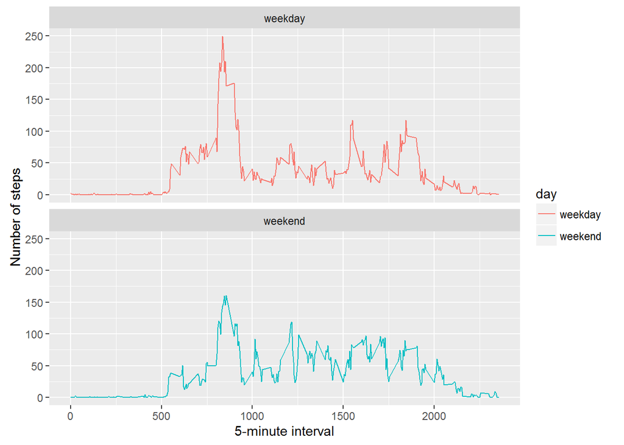

```r
activity_day <- (activity_filled %>% group_by(interval, day) %>% summarize(mean_steps = mean(steps)))

g <- ggplot(activity_day, aes(x= interval, y=mean_steps))
g + geom_line(aes(color=day)) + facet_wrap("day", nrow=2) +
        labs(x = "5-minute interval", y= "Number of steps")
```